# IODS course project

# About the project

In this course we will learn for example about data analysis and effective use of RMarkdown to better present our work done with R. We will also learn to use GitHub, that provides us the opportunity to share our work with other people.

Link to my GitHub repository is https://github.com/phbergma/IODS-project.

# Week ONE

This week was all about getting to know the programs and how to use them. I started by reading the GitHub instructions carefully since it was the most unfamiliar tool for me. I created an account for GitHub website and installed GitHub desktop from which I can update my diary with weekly excersices. On the GitHub website I could copy the project template made by course assistants. I could then modify those template for my own course diary.

I have been using R already for some years so this week’s DataCamp exercises were quite easy for me. They introduced the basics of R. First exercise was about loading a dataset and looking at what’s in it. With already provided code I drew a graph about people’s attitudes versus their exam points.

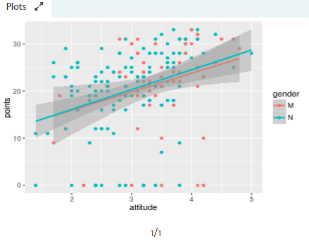

*Figure 1.1 Attitudes versus exam points. Screenshot from DataCamp.*

The rest of the exercises were quite straight-forward as well and by following the instructions they could be done pretty easily. It is always good to refresh one’s memory by doing the basic exercises because, to be honest, often I still have to look even the basics up in Google because I have such a short memory :) The most useful exercises for me were the ones were I had to create functions. Here follows an example of a function I created. It counts the number of apples I have if we know the number of apples I had before (my_apples) and the number of apples that have gone bad.

```r
# New function here!
good_apples_count <- function(apples, bad_apples=4) return(apples - bad_apples)

# How many good apples do you have?
good_apples_count(my_apples)
```

I hadn’t used RMarkdown before so there were definately many new things to learn this week! On this [cheatsheet](https://www.rstudio.com/wp-content/uploads/2016/03/rmarkdown-cheatsheet-2.0.pdf) I could find some useful tips on how everything works. First of all I learned the very basics. I learned to write on a document and how to add graphics and code to the document. Besides modifying the document templates, I also created a README-file for my GitHub repository page. Finally I also tried different themes on my course diary and ended up with *sandstone* because it seemed clear and simple enough for my taste.

# Week TWO

This week was about regression and model validation. So in practice, we are trying to explain variables with other variables in the data. In the case of continuous variable to explain, that’s done by creating a linear regression model with one dependent variable (the variable to be explained) and one or more explanatory variables. This week we are discovering linear models with some continuous variables.

First of all I created a dataset for my analysis. The Rscript with all the codes I used to create that can be found in my [repository](https://github.com/phbergma/IODS-project) in a file called create_learning.R. If you would like to have a more careful look at the variables in the original dataset, you can find the documentation [here](http://www.helsinki.fi/~kvehkala/JYTmooc/JYTOPKYS3-meta.txt). Just in case, my script for data wrangling can be also found here below:

```r
##Read the dataset in R
learning2014<-read.table("http://www.helsinki.fi/~kvehkala/JYTmooc/JYTOPKYS3-data.txt",header=T)

##Check the dimensions of the dataset
dim(learning2014)
##We can see that the dataset has 183 rows and 60 columns

##Check the structure of the dataset
str(learning2014)
##We can see that all variables except for gender are integer, so they have
##numeric values. Gender is a factor variable that has two levels, M and F for
##male and female

##Select the questions related to deep, surface and strategic learning
##as instructed in DataCamp
deep_questions <- c("D03", "D11", "D19", "D27", "D07", "D14", "D22", "D30","D07","D14","D22","D30")
surface_questions <- c("SU02","SU10","SU18","SU26", "SU05","SU13","SU21","SU29","SU08","SU16","SU24","SU32")
strategic_questions <- c("ST01","ST09","ST17","ST25","ST04","ST12","ST20","ST28")

##Access the dplyr-library
##install.packages("dplyr")
library(dplyr)

##Take the average of these theme questions to combine them into one variable
##(one variable for each theme)
deep_columns <- select(learning2014, one_of(deep_questions))
learning2014$deep <- rowMeans(deep_columns)
surface_columns <- select(learning2014, one_of(surface_questions))
learning2014$surf <- rowMeans(surface_columns)
strategic_columns <- select(learning2014, one_of(strategic_questions))
learning2014$stra<-rowMeans(strategic_columns)

##Create column 'attitude' by scaling the column "Attitude"
learning2014$attitude <- learning2014$Attitude/10

##Choose the necessary columns to keep
keep_columns <- c("gender","Age","attitude", "deep", "stra", "surf", "Points")

##Select the 'keep_columns' to create a new dataset
lrn2014 <- select(learning2014, one_of(keep_columns))

##Check which variables are in the new data
colnames(lrn2014)

##Change the name of the second column
colnames(lrn2014)[2] <- "age"

##Change the name of "Points" to "points"
colnames(lrn2014)[7]<-"points"

##Exclude the observations where points<=0
learning14<-subset(lrn2014,points>0)

##The data has now 166 observations and 7 variables as was in the instructions
##so Yayy!!

##Set working direcory to the IODS-project folder
setwd("C:/Users/Paula/Documents/GitHub/IODS-project")

##Save the dataset in the data-folder in the IODS-project folder
setwd("C:/Users/Paula/Documents/GitHub/IODS-project/data")
write.csv(learning14,"learning2014.csv",row.names=F)

##Read the data into R again to demonstrate that the dataset creation was successful
learning2014<-read.table("learning2014.csv",header=T,sep=",")
str(learning2014)
```

The next thing I did was reading the created dataset back into RStudio. First I needed to set a working directory into the folder where my dataset is and then load the csv-file from there. Then I changed the working directory to the folder where I actually want to keep everything related to the course.

```r
# Set working directory and call load the dataset into RStudio
setwd("C:/Users/Paula/Documents/GitHub/IODS-project/data")
students2014<-read.table("learning2014.csv",sep=",",header=T)
setwd("C:/Users/Paula/Documents/GitHub/IODS-project")
```

Reading through this weeks DataCamp exercises I realized that this week I wil need the packages dplyr, ggplot2 and GGally. Since I already installed them earlier (with the command install.packages(“packagename”)) I only had to call them from my package library.

```r
# Call packages needed this week, ggplot2, dplyr and GGally from the library
library(ggplot2)
library(dplyr)
library(GGally)
```

When my dataset was read into RStudio, I first took a good look at it. It has 166 observations and 7 variables. The variables are gender, age, attitude, deep, surf, stra and points. By looking at the structure and the summary of the data the reader can get a clearer image of what kind of variables are they and what kind of values they get in this dataset.

```r
str(students2014)
```

```
## 'data.frame':    166 obs. of  7 variables:
##  $ gender  : Factor w/ 2 levels "F","M": 1 2 1 2 2 1 2 1 2 1 ...
##  $ age     : int  53 55 49 53 49 38 50 37 37 42 ...
##  $ attitude: num  3.7 3.1 2.5 3.5 3.7 3.8 3.5 2.9 3.8 2.1 ...
##  $ deep    : num  3.75 2.88 3.88 3.5 3.75 ...
##  $ stra    : num  3.38 2.75 3.62 3.12 3.62 ...
##  $ surf    : num  2.58 3.17 2.25 2.25 2.83 ...
##  $ points  : int  25 12 24 10 22 21 21 31 24 26 ...
```

```r
summary(students2014)
```

```
##  gender       age           attitude          deep            stra
##  F:110   Min.   :17.00   Min.   :1.400   Min.   :1.625   Min.   :1.250
##  M: 56   1st Qu.:21.00   1st Qu.:2.600   1st Qu.:3.500   1st Qu.:2.625
##          Median :22.00   Median :3.200   Median :3.875   Median :3.188
##          Mean   :25.51   Mean   :3.143   Mean   :3.796   Mean   :3.121
##          3rd Qu.:27.00   3rd Qu.:3.700   3rd Qu.:4.250   3rd Qu.:3.625
##          Max.   :55.00   Max.   :5.000   Max.   :4.875   Max.   :5.000
##       surf           points
##  Min.   :1.583   Min.   : 7.00
##  1st Qu.:2.417   1st Qu.:19.00
##  Median :2.833   Median :23.00
##  Mean   :2.787   Mean   :22.72
##  3rd Qu.:3.167   3rd Qu.:27.75
##  Max.   :4.333   Max.   :33.00
```

We can see that gender is a factor variable that has two levels, M for male and F for female, age and points are integer variables: Age varies between 17 and 55 while the median age is 22 years, points vary between 7 and 33 and the median value is 23. The median value is the value we get if we put all the values in order and take the one that is in the middle. The rest of the variables are numeric. In fact, deep, stra and surf are variables created by combining other variables in the way presented in the create_learning2014.R-script. deep contains variables connected to deep learning, stra variables connected to studying strategies and surf variables connected to surface learning. attitude is just the original Attitude variable divided by 10 so it will be on the same scale as the rest of the numeric variables in this data. points-variable tells us how much points each student in the dataset got on the exam.

The task was to find variables that could explain the variation of the variable points. So I took a look at the scatterplots between each of the variables in the data but left out gender because for a binary variable scatterplot is not really a meaningful way to go.

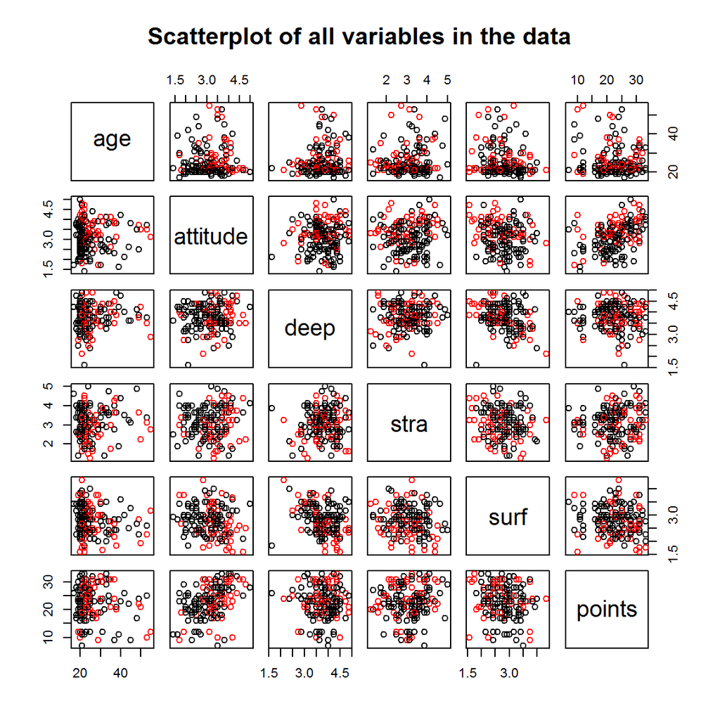

*Figure 2.1 Scatterplot of all variables in the data.*

```r
# Draw a scatter plot matrix of all the variables except gender in students2014.
pairs(students2014[-1],col=students2014$gender,
      main="Scatterplot of all variables in the data")
```

We can see that attitude seems to correlate somewhat strongly with points. Maybe some kind of correlation could be seen also between some other variables but at least for me this graph is not very clear.

So I tried to look at the correlations better by plotting it with the instructions found from this week’s DataCamp. I drew a plot that presents the correlations of each variable with each variable, for both genders separately and for all the observations, a scatterplot between each pair of variables and a density plot of each variable. For gender that is a binary variable it presents a boxplot that compares how the summary statistics of each variables vary according to gender. It also presents a histogram of a frequency distribution for each variable for both genders separately. In all the plots males are marked with the blueish color and women with red.

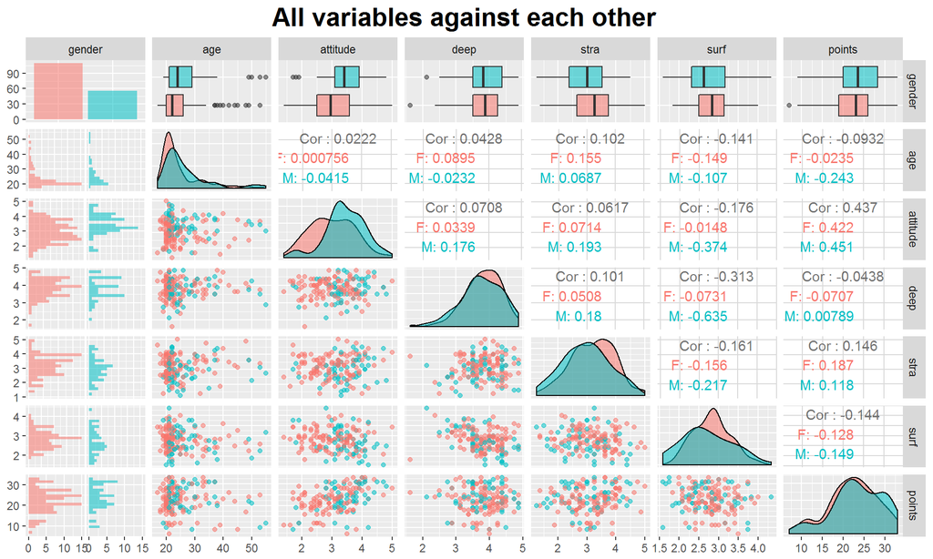

*Figure 2.2 All variables against each other.*

```r
# create and draw a more advanced plot matrix with ggpairs()
p2 <- ggpairs(students2014, mapping = aes(col=gender,alpha=0.3),
             lower = list(combo = wrap("facethist", bins = 20))) +
  ggtitle("All variables against each other") +
  theme(plot.title = element_text(hjust = 0.5,size=20,face='bold'))
p2
```

We can see that there is the strongest correlation between points and attitude, so that affirms what I was suspecting based on a scatterplot. The correlation between those two is 0.437. I plotted those two variables in a scatterplot to take a better look.

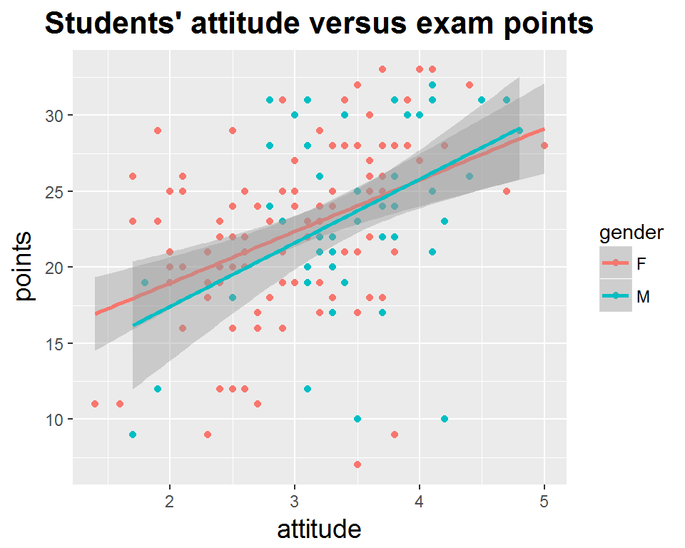

*Figure 2.3 Students’ attitude versus exam points.*

```r
# Define and draw a plot about students' attitude versus exam points and draw it
p1 <- ggplot(students2014, aes(x = attitude, y = points, col=gender)) +
  geom_point() + geom_smooth(method="lm") +
  ggtitle("Students' attitude versus exam points")+
  theme(plot.title = element_text(hjust = 0.5,size=16,face='bold'),
        axis.title= element_text(hjust = 0.5,size=14))
p1
```

The second and the third strongest covariates for points are stra (0.146) and surf (-0.144). Usually age and gender are always taken into the linear model as explanatory variables but in this case the correlations were so small that I decided not to do that. (Also I tried to make a linear regression model with those variables and they were by no means significant so for the purposes of this exercise I will just assume that points doesn’t depend on either age or gender.) I chose attitude, stra and surf as my explanatory variables and formed a linear model called my_model1.

```r
# Try to explain points with other variables in the data by fitting
# a linear model
my_model1<-lm(points~attitude+stra+surf,data=students2014)
summary(my_model1)
```

```
##
## Call:
## lm(formula = points ~ attitude + stra + surf, data = students2014)
##
## Residuals:
##      Min       1Q   Median       3Q      Max
## -17.1550  -3.4346   0.5156   3.6401  10.8952
##
## Coefficients:
##             Estimate Std. Error t value Pr(>|t|)
## (Intercept)  11.0171     3.6837   2.991  0.00322 **
## attitude      3.3952     0.5741   5.913 1.93e-08 ***
## stra          0.8531     0.5416   1.575  0.11716
## surf         -0.5861     0.8014  -0.731  0.46563
## ---
## Signif. codes:  0 '***' 0.001 '**' 0.01 '*' 0.05 '.' 0.1 ' ' 1
##
## Residual standard error: 5.296 on 162 degrees of freedom
## Multiple R-squared:  0.2074, Adjusted R-squared:  0.1927
## F-statistic: 14.13 on 3 and 162 DF,  p-value: 3.156e-08
```

We can see from the summary output of the model that the only statistically significant explanatory variable is attitude. It has a p-value of 1.93e-08 < 0.001 whereas the others’ p-values are > 0.05.

Let’s take a look at the rest of the summary output though. In this model, when the attitude increases by 1, the points increase by 3.3952 and when surf increases by one, the points decrease by 0.5861.

We can then see how much this model explains of the variation of points when we look at the multiple R-squared or the adjusted R-squared. It is usually better to look at the adjusted R-squared because the multiple R-squared increases no matter which variables you add to the model whereas the adjusted R-squared takes this into account and “punishes” for useless variables. The adjusted R-squared in this model is 0.1927 which means that this model explains 19.27 % of the variation of points. In other words, more than 80 % of this variable’s variation still remains a mystery, as is the case in many variables in life. There could be other variables that explain points as well, such as family background, language skills, reading problems, genetics, a flue, you name it! So it is quite normal that the models can’t explain all the variation, but I think in this case we could do better.

I noticed that the variable surf correlates relatively strongly with both attitude and stra. Usually what is hoped is that the explanatory variables would be independent from each others. So I decided to remove that from the analysis to see if it would be better this way.

```r
my_model2<-lm(points~attitude+stra,data=students2014)
summary(my_model2)
```

```
##
## Call:
## lm(formula = points ~ attitude + stra, data = students2014)
##
## Residuals:
##      Min       1Q   Median       3Q      Max
## -17.6436  -3.3113   0.5575   3.7928  10.9295
##
## Coefficients:
##             Estimate Std. Error t value Pr(>|t|)
## (Intercept)   8.9729     2.3959   3.745  0.00025 ***
## attitude      3.4658     0.5652   6.132 6.31e-09 ***
## stra          0.9137     0.5345   1.709  0.08927 .
## ---
## Signif. codes:  0 '***' 0.001 '**' 0.01 '*' 0.05 '.' 0.1 ' ' 1
##
## Residual standard error: 5.289 on 163 degrees of freedom
## Multiple R-squared:  0.2048, Adjusted R-squared:  0.1951
## F-statistic: 20.99 on 2 and 163 DF,  p-value: 7.734e-09
```

Unfortunately we can still see that attitude is the only statistically significant explanatory variable. So what is left to do is to construct a model that has only one explanatory variable, attitude.

```r
my_model3<-lm(points~attitude,data=students2014)
summary(my_model3)
```

```
##
## Call:
## lm(formula = points ~ attitude, data = students2014)
##
## Residuals:
##      Min       1Q   Median       3Q      Max
## -16.9763  -3.2119   0.4339   4.1534  10.6645
##
## Coefficients:
##             Estimate Std. Error t value Pr(>|t|)
## (Intercept)  11.6372     1.8303   6.358 1.95e-09 ***
## attitude      3.5255     0.5674   6.214 4.12e-09 ***
## ---
## Signif. codes:  0 '***' 0.001 '**' 0.01 '*' 0.05 '.' 0.1 ' ' 1
##
## Residual standard error: 5.32 on 164 degrees of freedom
## Multiple R-squared:  0.1906, Adjusted R-squared:  0.1856
## F-statistic: 38.61 on 1 and 164 DF,  p-value: 4.119e-09
```

Now we can see that the p-value of attitude is 4.12e-09 and that the model explains 18.56 % of the variation in points. According to this model if the attitude increases by 1, the points increase by 3.5255. A similar relation can be seen also in the scatterplot drawn before.

Finally I drew some diagnostic plots to see the goodness of fit of the model I created.

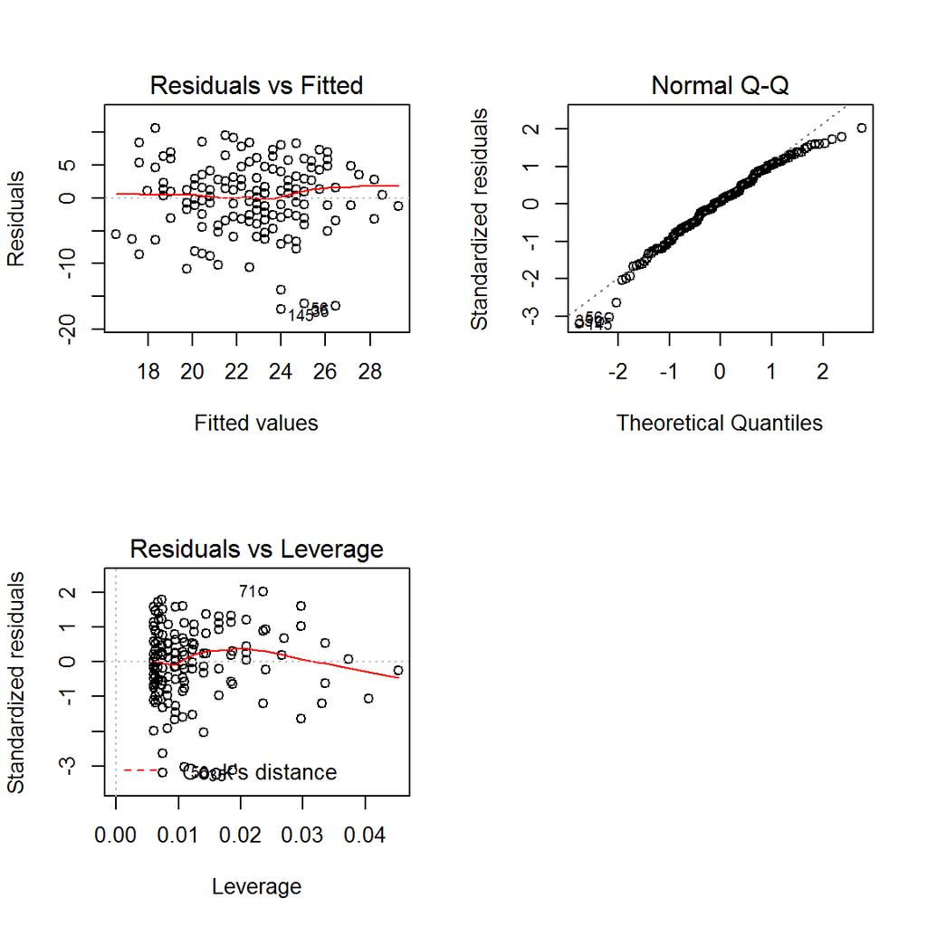

*Figure 2.4 Diagnostic plots.*

```r
# Draw diagnostic plots for the model 3 using the plot() function. Choose the plots 1, 2 and 5
par(mfrow=c(2,2))
plot(my_model3,which=c(1,2,5))
```

In the first plot we can see residuals versus the fitted values. According to the assumptions of linear model, they should be vertically randomly distributed on both sides of zero because in the ideal situation the residual that the model cannot explain will be random. So we are not missing some systematic thing going on that we didn’t take into account. Luckily it seems that our model is quite successful in that aspect. A little bit more points can be seen below zero than above but this is not drammatic in my opinion. The Q-Q-plot tells the same story - The more normally distributed the standardized residuals are, the better. This is because the linear model assumes the standardized residuals to be normally distributed. In this case the points are quite beautifully on a straight line, except for some points in the bottom left and top right. The points in this and the previous plot are exactly the same but they are just plotted from a little bit different point of view.

The third plot helps in spotting potential outliers that could influence the regression results. If there are observations outside the Cook’s distance lines, these are the kind of outliers that have such an effect in the analysis that if we remove them, the outcome could be different. This time the Cook’s distance lines are not even visible so the observations are well inside them. So nothing to worry, according to this plot there are no such outliers that could distort the analysis results.

# Week THREE

This week is about logistic regression. Logistic regression is a common approach when we want to construct a regression model where the dependent variable is binary. Logistic regression model gives us a probability of the occurrence of the event (binary variable) with certain values of the explanatory variables. This probability is according to that model, and would be different in another model.

Here is the code for the data wrangling part:

```r
#################
#Paula Bergman
#7.2.2017
#Data wrangling to create the alcohol consumption dataset
#Data downloaded from the website
#https://archive.ics.uci.edu/ml/machine-learning-databases/00356/

#Set the working directory
setwd("C:/Users/Paula/Documents/GitHub/IODS-project/data")

#Read the datasets into RStudio
mat<-read.table("student-mat.csv",header=T,sep=";")
por<-read.table("student-por.csv",header=T,sep=";")

#Check the dimensions and the structure of the datasets
dim(mat)
str(mat)
#We can see that the mat-data  consists of 395 observations and 33 variables,
#17 of which are of type factor and the rest integer.
dim(por)
str(por)
#We can see that the por-data consists of 649 observations and 33 variables,
#which are exactly the same than in the mat-data.

#Access the dplyr library
library(dplyr)

#Join the datasets by using the variables "school", "sex", "age", "address",
#"famsize", "Pstatus", "Medu", "Fedu", "Mjob", "Fjob", "reason", "nursery",
#"internet" as (student) identifiers. This way only the students present in
#both datasets will be included in the data
join_by <- c("school","sex","age","address","famsize","Pstatus","Medu","Fedu",
             "Mjob","Fjob","reason","nursery","internet")
mat_por <- inner_join(mat, por, by = join_by)
mat_por<-inner_join(mat,por,by=join_by,suffix=c(".mat",".por"))

dim(mat_por)
str(mat_por)
#Now the dataset has 382 observations and 53 variables. Those variables that I
#used for joining, are there only once but for the rest of the variables there are
#two of each, separated with the endings .mat and .por

#Create a new data frame with only the joined columns
alc <- select(mat_por, one_of(join_by))

#The columns in the datasets which were not used for joining the data
notjoined_columns <- colnames(mat)[!colnames(mat) %in% join_by]

#For every column name not used for joining...
for(column_name in notjoined_columns) {
  #select two columns from 'math_por' with the same original name
  two_columns <- select(mat_por, starts_with(column_name))
  #select the first column vector of those two columns
  first_column <- select(two_columns, 1)[[1]]

  #if that first column vector is numeric...
  if(is.numeric(first_column)) {
    #take a rounded average of each row of the two columns and
    #add the resulting vector to the alc data frame
    alc[column_name] <- round(rowMeans(two_columns))
  } else { # else if it's not numeric...
    #add the first column vector to the alc data frame
    alc[column_name] <- select(two_columns, 1)[[1]]
  }
}

#Create an alcohol consumption variable alc_use to the joined data by
#taking the average of alcohol consumption variables in the data.
#Those are Dalc = Daily alcohol consumption and Walc = Weekly alcohol consumption
alc$alc_use<-(alc$Dalc+alc$Walc)/2

#Create a variable high_use to the joined data to describe whether the student
#uses alcohol a high amount or not
alc$high_use<-ifelse(alc$alc_use>2,TRUE,FALSE)

#Glimpse at the joined and modified data to make sure everything is in order
glimpse(alc)

#It seems that everything is in the order: There are 382 observations and
#35 variables as it is supposed to be.

#Save the joined dataset into the data-folder in csv-form. Since the working
#directory is already set into that folder, it doesn't have to be referenced
#anymore.
write.csv(alc,"alc.csv",row.names=F)
```

First I read back into RStudio the dataset created in data wrangling part and checked the names of the variables in the dataset. I also called the possibly necessary packages from library.

```r
setwd("C:/Users/Paula/Documents/GitHub/IODS-project/data")
alc<-read.table("alc.csv",header=T,sep=",")
names(alc)
```

```
##  [1] "school"     "sex"        "age"        "address"    "famsize"
##  [6] "Pstatus"    "Medu"       "Fedu"       "Mjob"       "Fjob"
## [11] "reason"     "nursery"    "internet"   "guardian"   "traveltime"
## [16] "studytime"  "failures"   "schoolsup"  "famsup"     "paid"
## [21] "activities" "higher"     "romantic"   "famrel"     "freetime"
## [26] "goout"      "Dalc"       "Walc"       "health"     "absences"
## [31] "G1"         "G2"         "G3"         "alc_use"    "high_use"
```

```r
# Call packages needed this week, ggplot2, dplyr and GGally from the library
library(ggplot2)
library(dplyr)
library(GGally)
```

This is a dataset of students of maths course and Portuguese course. (Data Set Information: P. Cortez and A. Silva. Using Data Mining to Predict Secondary School Student Performance. In A. Brito and J. Teixeira Eds., Proceedings of 5th FUture BUsiness TEChnology Conference (FUBUTEC 2008) pp. 5-12, Porto, Portugal, April, 2008, EUROSIS, ISBN 978-9077381-39-7.) It consists of 35 variables, describing students’ basic information, family background, free time activities, school performance and alcohol usage. The last two variables were created in the data wrangling part and explanations can be found in that code, and the more detailed description of the rest of the variables can be found [here](https://archive.ics.uci.edu/ml/datasets/STUDENT+ALCOHOL+CONSUMPTION#).

The purpose of this weeks analysis is to study the relationship between high/low alcohol consumption and some other variables of my choice in the data. I chose

**Pstatus**, which tells whether the parents of the student are together (=T) or apart (=A) (dicotomous/binary variable)

**age**, which tells the student’s age in years (between 15 and 22, numeric variable)

**studytime**, which tells how much time the student spends weekly studying (numeric variable: 1 - <2 hours, 2 - 2 to 5 hours, 3 - 5 to 10 hours, or 4 - >10 hours)

My hypothesis for the parents’ status is that if the parents are apart, it is more likely for the student to use high amount of alcohol. I also suppose that the older the student is, more probable is high alcohol consumption. I also would guess that the less time student spends studying, the more they use alcohol and the more absences they have from school the more they use alcohol. I hypotesize that the last two variables indicate that the student has less interest in education in general and I think that could be one predictive factor for high alcohol usage.

## Graphical overview of the explanatory variables

I first looked at these variables graphically, starting from the number of absences. I drew a boxplot where the boxes represent low users and high users.

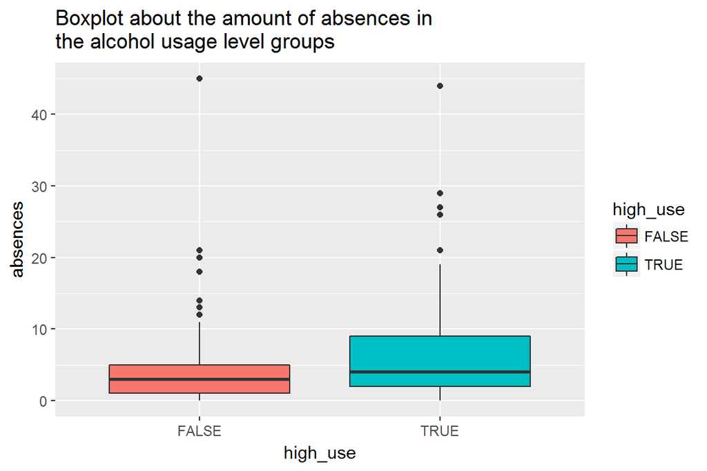

*Figure 3.1 Amount of absences in boxes by high usage of alcohol.*

```r
# Plot
qplot(high_use, absences, data=alc, geom="boxplot", fill=high_use,main="Boxplot about the amount of absences in \nthe alcohol usage level groups")
```

By looking at the boxes, especially the median value, it seems that the absences are more likely in the high use group than in the group of students who don’t use high amounts of alcohol. We can also see that both groups have an outlier. This could be useful to remember later.

To understand better the relationship between Pstatus and high_use, I decided to use the traditional way and to crosstabulate them.

```r
attach(alc)
t<-table(high_use,Pstatus)
t
```

```
##         Pstatus
## high_use   A   T
##    FALSE  26 242
##    TRUE   12 102
```

```r
chisq.test(high_use,Pstatus)
```

```
##
##  Pearson's Chi-squared test with Yates' continuity correction
##
## data:  high_use and Pstatus
## X-squared = 0.0035591, df = 1, p-value = 0.9524
```

It seems that those two variables don’t depend on each others. I also did a Chi Square test to search confirmation to my speculations. P-value is very high which indicates that these two variables would not depend on each others, just like I suspected based on the contingency table.

Then I decided to take a better look at the relationship between high_use and studytime. The latter is a categorical variable with 4 categories so I decided that the best way to go would be to draw a grouped barplot.

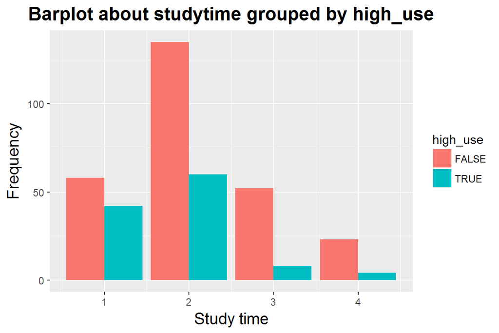

*Figure 3.2 Studying time grouped by high usage of alcohol.*

```r
ggplot(alc, aes(studytime, fill=high_use)) + geom_bar(position="dodge") +
  ggtitle("Barplot about studytime grouped by high_use")+ xlab("Study time") + ylab("Frequency") +
  theme(plot.title = element_text(hjust = 0.5,size=16,face='bold'),
        axis.title= element_text(hjust = 0.5,size=14))
```

We can see that bigger proportion of those high amount users fall into the first two categories of studying than those who arent high amount users. We could thus suspect that maybe the variables have some kind of connection to each other.

Then I looked at the relationship between high_use and age by drawing another grouped barplot.

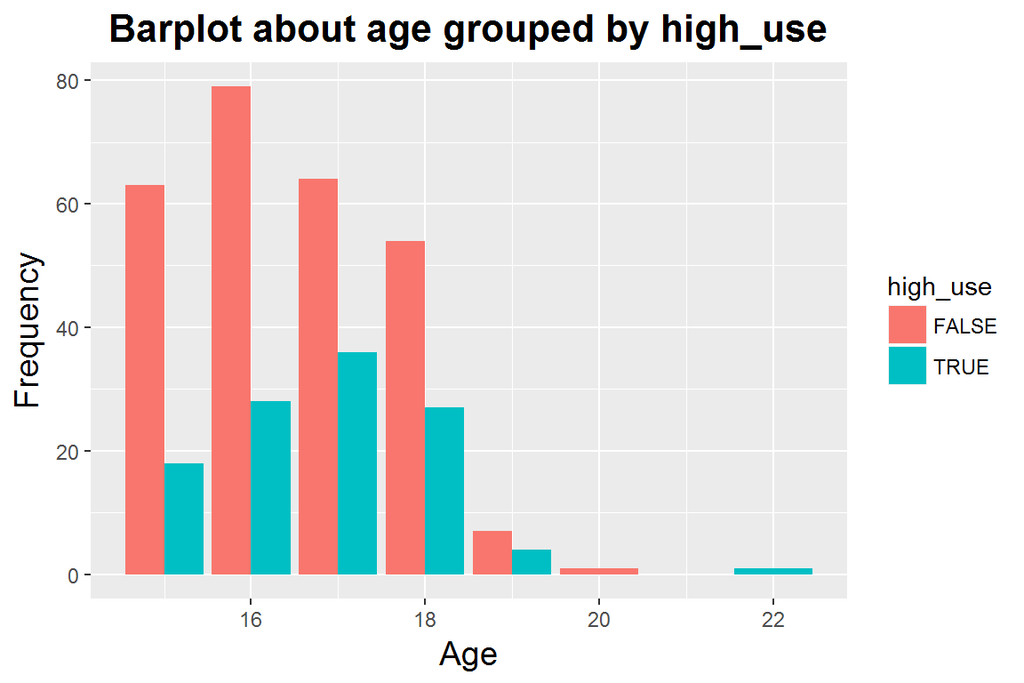

*Figure 3.3 Age grouped by high usage of alcohol.*

```r
ggplot(alc, aes(age, fill=high_use)) + geom_bar(position="dodge") +
  ggtitle("Barplot about age grouped by high_use")+ xlab("Age") + ylab("Frequency") +
  theme(plot.title = element_text(hjust = 0.5,size=16,face='bold'),
        axis.title= element_text(hjust = 0.5,size=14))
```

It seems that high_use peaks at age seventeen and the low use peaks at age sixteen. Anyway the distributions don’t differ as much as in Figure 3.2.

## Logistic Regression analysis

Even though some of the graphics didn’t quite support my initial hypothesis, I still decided to go on and use all of them in my logistic regression model. So here it is:

```r
#Construct the logistic regression model
mymodel1 <- glm(high_use~Pstatus+age+studytime+absences,data=alc,family="binomial")

#Print out a summary of the model
summary(mymodel1)
```

```
##
## Call:
## glm(formula = high_use ~ Pstatus + age + studytime + absences,
##     family = "binomial", data = alc)
##
## Deviance Residuals:
##     Min       1Q   Median       3Q      Max
## -2.2062  -0.8465  -0.6516   1.1557   2.3181
##
## Coefficients:
##             Estimate Std. Error z value Pr(>|z|)
## (Intercept) -3.21051    1.73401  -1.851 0.064099 .
## PstatusT     0.11619    0.40011   0.290 0.771511
## age          0.17891    0.10218   1.751 0.079961 .
## studytime   -0.56071    0.15711  -3.569 0.000358 ***
## absences     0.07674    0.02306   3.328 0.000874 ***
## ---
## Signif. codes:  0 '***' 0.001 '**' 0.01 '*' 0.05 '.' 0.1 ' ' 1
##
## (Dispersion parameter for binomial family taken to be 1)
##
##     Null deviance: 465.68  on 381  degrees of freedom
## Residual deviance: 430.39  on 377  degrees of freedom
## AIC: 440.39
##
## Number of Fisher Scoring iterations: 4
```

```r
#Print out the coefficients of the model
coef(mymodel1)
```

```
## (Intercept)    PstatusT         age   studytime    absences
## -3.21050861  0.11619233  0.17890859 -0.56070924  0.07674017
```

The results confirm what we have seen earlier in the plots and tabulations. Studytime and the number of absences seem to be statistically significant ( p < 0.05 ) in the model whereas parents’ status and age don’t seem to be that interesting.

To understand thoroughly the results of logistic regression there are a couple of terms we need to know. The following explanation of the terms is based on [Akin menetelmablogi](https://tilastoapu.wordpress.com/tag/odds/) that is unfortunately only in Finnish. Many statistical terms are explained there in a very simple way. But back to the terms to understand logistic regression. First of all there is *odds*. Odds is simply the probability divided by the opposite of that probability so *odds* = p / (1 - p). So it is the relation between two probabilities. If we know the odds and want to find out p, we can get it like this: p = odds / ( 1 + odds ).

Then there is *logit* that is the natural logarithm of *odds*. So to express it in mathematical terms *logit* = log( odds ). If we know the logit value, we can find out the odds like this: odds = exp( logit ).

By putting these together we can calculate the probability like this: p = ( exp( logit ) ) / ( 1 + exp( logit ) ).

The interpretation can be compared to linear regression but this time the dependent variable is not the variable of interest itself but the logit. So in this case the increase in age and absences increases the logit and the increas in studytime decreases the logit. Actually those variables that increase the logit also increase the probability of being a high amount user and the opposite. (As we remember p = ( exp( logit ) ) / ( 1 + exp( logit ) ). This approaches to 1 the bigger the logit value gets.).

The interpretation for Pstatus is a little bit different because it is a factor variable. Only the level that the parents are still together is included in the model. PstatusT denotes the difference between PstatusT and PstatusA. The coefficient of PstatusA is actually the intercept and so the coefficient of PstatusT would actually be -3.21051 + 0.11619 = -3.09432. (The source of this information is [this question and answer](http://stats.stackexchange.com/questions/60817/significance-of-categorical-predictor-in-logistic-regression) posted on Stack Overflow.)

The null deviance suggests that there might be some overdispersion in the model, because it is bigger than the number of degrees of freedom (In the perfect model the null deviance = 0.)

Lets then look at the odds ratios and their confidence intervals in this model. Actually we could also get the odds ratios just by exponentiating the coefficients from the summary of the model, but there is an easier way to do this by R commands.

```r
#Compute odds ratios (OR)
OR<-coef(mymodel1)%>%exp

# compute confidence intervals (CI)
CI<-confint(mymodel1)%>%exp
# print out the odds ratios with their confidence intervals
cbind(OR,CI)
```

```
##                     OR       2.5 %    97.5 %
## (Intercept) 0.04033609 0.001288954 1.1731792
## PstatusT    1.12321188 0.525018003 2.5527357
## age         1.19591143 0.980186552 1.4646058
## studytime   0.57080408 0.415360010 0.7700019
## absences    1.07976149 1.034162734 1.1321627
```

When the odds ratio is greater than 1, the increase in the explanatory variable increases the risk of the occurrence of the dependent variable (in this case high_use = TRUE) and the opposite if the odds ratio is smaller than one. So in this case it seems that the increase in PstatusT, age and absences seem to increase the risk whereas the increase in studytime decreases the risk. Although the confidence interval of age includes 1, that means that it is possible that the odds ratio would be 1 so that age would not have any effect on the risk.

## Predictive power of the model

```r
#Fit the new model
mymodel2<-glm(high_use~studytime+absences+sex,data=alc,family="binomial")

#Predict() the probability of high_use
probabilities<-predict(mymodel2,type="response")

#Add the predicted probabilities to 'alc'
alc<-mutate(alc,probability=probabilities)

#Use the probabilities to make a prediction of high_use
alc<-mutate(alc,prediction=probability>0.5)

#Tabulate the target variable versus the predictions
table(high_use=alc$high_use,prediction=alc$prediction)
```

```
##         prediction
## high_use FALSE TRUE
##    FALSE   258   10
##    TRUE     88   26
```

```r
#Tabulate the target variable versus the predictions
t<-table(high_use=alc$high_use,prediction=alc$prediction)%>%prop.table%>%addmargins
```

The same can also be seen in Figure 3.4.

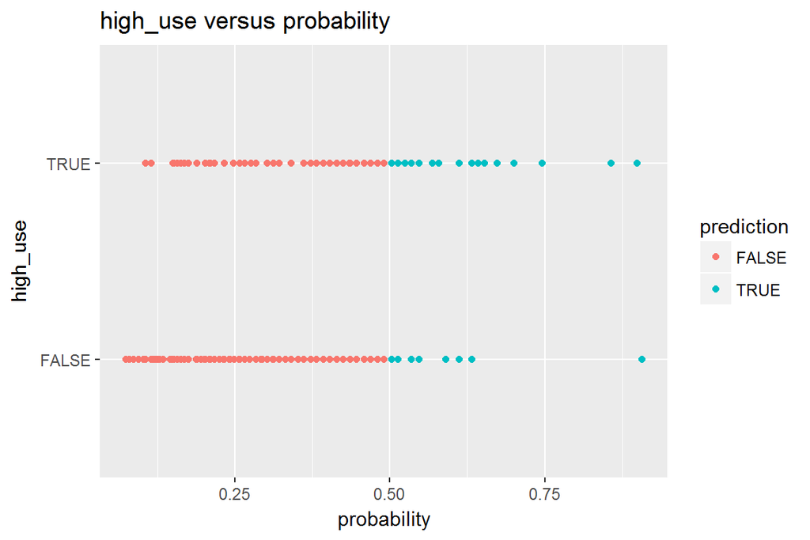

*Figure 3.4 High usage of alcohol versus probability.*

```r
#Draw a plot of 'high_use' versus 'probability' in 'alc'
g<-ggplot(alc,aes(x=probability,y=high_use,col=prediction)) + geom_point() + ggtitle("high_use versus probability")
g
```

If we compare these results to a simple guessing strategy of for example tossing a coin, this prediction model performs very well. By tossing a coin we would predict approximately 50 percent of the values being negative and 50 percent positive, and since these are not the actual proportion, the prediction would go terribly wrong. So I would say that it is better to base the prediction model on the actual data than anything else.

Lets still look at the 10-fold cross-validation.

```r
#Define a loss function (average prediction error)
loss_func<-function(class,prob){
  n_wrong<-abs(class-prob)>0.5
  mean(n_wrong)
}

#Compute the average number of wrong predictions in the (training) data
loss_func(alc$high_use,alc$probability)
```

```
## [1] 0.2565445
```

```r
#K-fold cross-validation
library(boot)
cv<-cv.glm(data=alc,cost=loss_func,glmfit=mymodel2,K=10)
cv$delta[1]
```

```
## [1] 0.2565445
```

My model seems to have the average of wrong predictions pretty close to the one in DataCamp model.

# Week FOUR

This week we learned about clustering and classification. That was quite a new subject for me so I was eager to learn it. We are using Boston-data that can be found in MASS-package. So first I called the MASS-package from library and accessed the dataset from there.

```r
#Call the MASS package
library(MASS)

#Load the data
data("Boston")
```

Then I explored the data by looking at the structure and the summries of the data as usual.

```r
#Explore the data
str(Boston)
```

```
## 'data.frame':    506 obs. of  14 variables:
##  $ crim   : num  0.00632 0.02731 0.02729 0.03237 0.06905 ...
##  $ zn     : num  18 0 0 0 0 0 12.5 12.5 12.5 12.5 ...
##  $ indus  : num  2.31 7.07 7.07 2.18 2.18 2.18 7.87 7.87 7.87 7.87 ...
##  $ chas   : int  0 0 0 0 0 0 0 0 0 0 ...
##  $ nox    : num  0.538 0.469 0.469 0.458 0.458 0.458 0.524 0.524 0.524 0.524 ...
##  $ rm     : num  6.58 6.42 7.18 7 7.15 ...
##  $ age    : num  65.2 78.9 61.1 45.8 54.2 58.7 66.6 96.1 100 85.9 ...
##  $ dis    : num  4.09 4.97 4.97 6.06 6.06 ...
##  $ rad    : int  1 2 2 3 3 3 5 5 5 5 ...
##  $ tax    : num  296 242 242 222 222 222 311 311 311 311 ...
##  $ ptratio: num  15.3 17.8 17.8 18.7 18.7 18.7 15.2 15.2 15.2 15.2 ...
##  $ black  : num  397 397 393 395 397 ...
##  $ lstat  : num  4.98 9.14 4.03 2.94 5.33 ...
##  $ medv   : num  24 21.6 34.7 33.4 36.2 28.7 22.9 27.1 16.5 18.9 ...
```

```r
summary(Boston)
```

```
##       crim                zn             indus            chas
##  Min.   : 0.00632   Min.   :  0.00   Min.   : 0.46   Min.   :0.00000
##  1st Qu.: 0.08204   1st Qu.:  0.00   1st Qu.: 5.19   1st Qu.:0.00000
##  Median : 0.25651   Median :  0.00   Median : 9.69   Median :0.00000
##  Mean   : 3.61352   Mean   : 11.36   Mean   :11.14   Mean   :0.06917
##  3rd Qu.: 3.67708   3rd Qu.: 12.50   3rd Qu.:18.10   3rd Qu.:0.00000
##  Max.   :88.97620   Max.   :100.00   Max.   :27.74   Max.   :1.00000
##       nox               rm             age              dis
##  Min.   :0.3850   Min.   :3.561   Min.   :  2.90   Min.   : 1.130
##  1st Qu.:0.4490   1st Qu.:5.886   1st Qu.: 45.02   1st Qu.: 2.100
##  Median :0.5380   Median :6.208   Median : 77.50   Median : 3.207
##  Mean   :0.5547   Mean   :6.285   Mean   : 68.57   Mean   : 3.795
##  3rd Qu.:0.6240   3rd Qu.:6.623   3rd Qu.: 94.08   3rd Qu.: 5.188
##  Max.   :0.8710   Max.   :8.780   Max.   :100.00   Max.   :12.127
##       rad              tax           ptratio          black
##  Min.   : 1.000   Min.   :187.0   Min.   :12.60   Min.   :  0.32
##  1st Qu.: 4.000   1st Qu.:279.0   1st Qu.:17.40   1st Qu.:375.38
##  Median : 5.000   Median :330.0   Median :19.05   Median :391.44
##  Mean   : 9.549   Mean   :408.2   Mean   :18.46   Mean   :356.67
##  3rd Qu.:24.000   3rd Qu.:666.0   3rd Qu.:20.20   3rd Qu.:396.23
##  Max.   :24.000   Max.   :711.0   Max.   :22.00   Max.   :396.90
##      lstat            medv
##  Min.   : 1.73   Min.   : 5.00
##  1st Qu.: 6.95   1st Qu.:17.02
##  Median :11.36   Median :21.20
##  Mean   :12.65   Mean   :22.53
##  3rd Qu.:16.95   3rd Qu.:25.00
##  Max.   :37.97   Max.   :50.00
```

- crim = per capita crime rate by town.
- zn = proportion of residential land zoned for lots over 25,000 sq.ft.
- indus = proportion of non-retail business acres per town.
- chas = Charles River dummy variable (= 1 if tract bounds river; 0 otherwise).
- nox = nitrogen oxides concentration (parts per 10 million).
- rm = average number of rooms per dwelling.
- age = proportion of owner-occupied units built prior to 1940.
- dis = weighted mean of distances to five Boston employment centres.
- rad = index of accessibility to radial highways.
- tax = full-value property-tax rate per $10,000.
- ptratio = pupil-teacher ratio by town.
- black = 1000(Bk - 0.63)^2 where Bk is the proportion of blacks by town.
- lstat = lower status of the population (percent).
- medv = median value of owner-occupied homes in $1000s.

I then looked at the graphics of the variables. I decided to look at the density plots to understand better the distributions of the variables.

```r
#Access the tidyverse libraries tidyr, dplyr, ggplot2
library(tidyr); library(dplyr); library(ggplot2)
```

```r
#Use gather() to gather columns into key-value pairs and then glimpse() at the resulting data
gather(Boston) %>% glimpse
```

```
## Observations: 7,084
## Variables: 2
## $ key   <chr> "crim", "crim", "crim", "crim", "crim", "crim", "crim", ...
## $ value <dbl> 0.00632, 0.02731, 0.02729, 0.03237, 0.06905, 0.02985, 0....
```

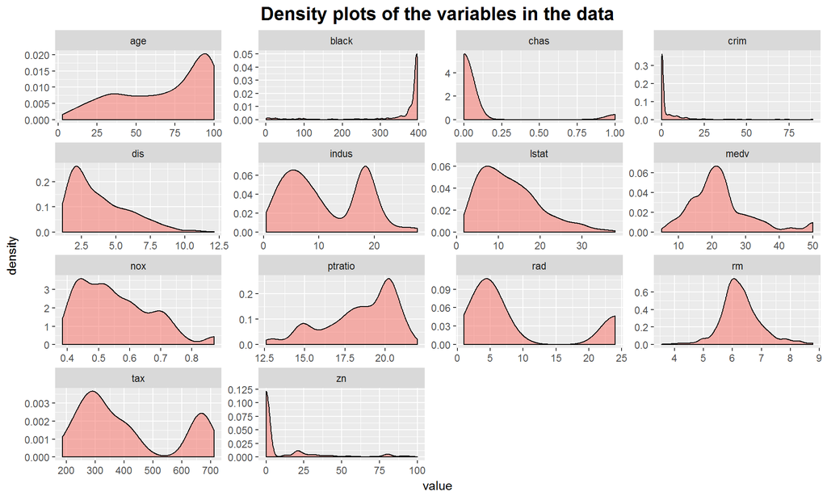

*Figure 4.1 Density plots of the variables in Boston-data.*

```r
#Draw a density plot of each variable
gather(Boston) %>% ggplot(aes(value,fill="#99999",alpha=0.3)) + facet_wrap("key", scales = "free") +
  geom_density() +
  ggtitle("Density plots of the variables in the data") +
  theme(plot.title = element_text(hjust = 0.5,size=16,face='bold'),legend.position="none")
```

We can see for example that the average number of rooms per dwelling (rm) seems quite normally distributed. Crime rate variable (crim) peaks at zero which is a good thing: Most of the suburbs have very low crime rate per capita. It seems that there are not so many pupils per teacher, the figure peaks at a bit more than twenty, and as we saw from the summaries, the maximum was actually not more than 22. I remember from my own childhood that I had 31 classmates when I was 9 years old!

I took a look at the relationships between variables by plotting them against each other.

```r
library("GGally")
```

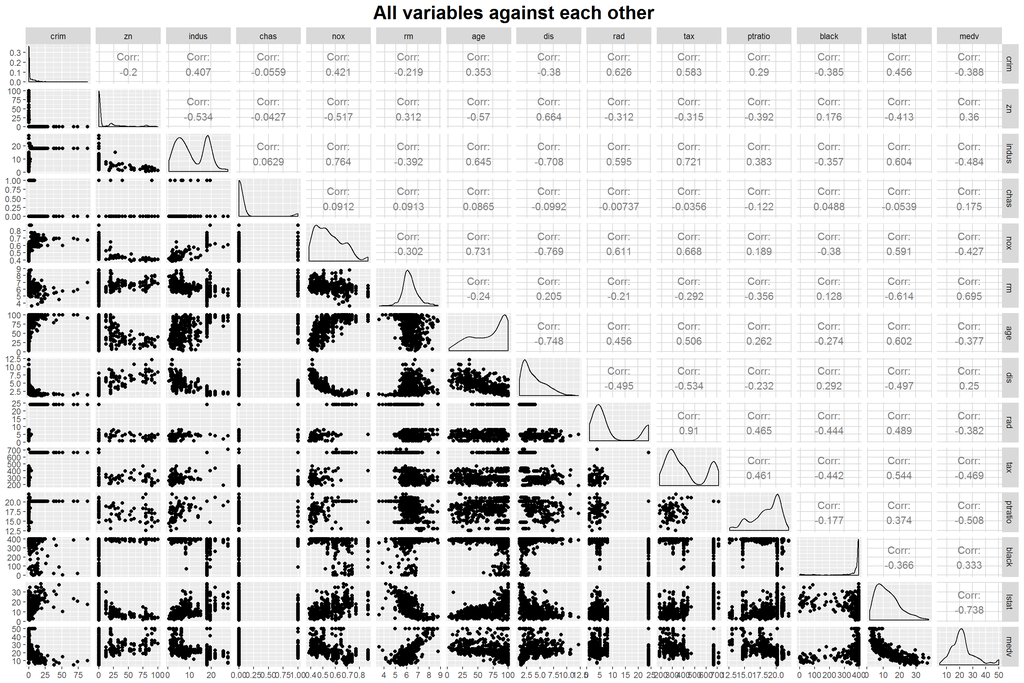

*Figure 4.2 All variables against each other.*

```r
#Create and draw a more advanced plot matrix with ggpairs()
p2 <- ggpairs(Boston,
             lower = list(combo = wrap("facethist", bins = 20))) +
  ggtitle("All variables against each other") +
  theme(plot.title = element_text(hjust = 0.5,size=20,face='bold'))
p2
```

Overall it seems that quite many variables are correlated with each others. Especially high correlation can be found for example between number of rooms per dwelling (rm) and median value of owner-occupied homes in $1000s (medv) which is actually quite intuitive. I decided to draw yet another plot to visualize the correlations in a more easy way to look at.

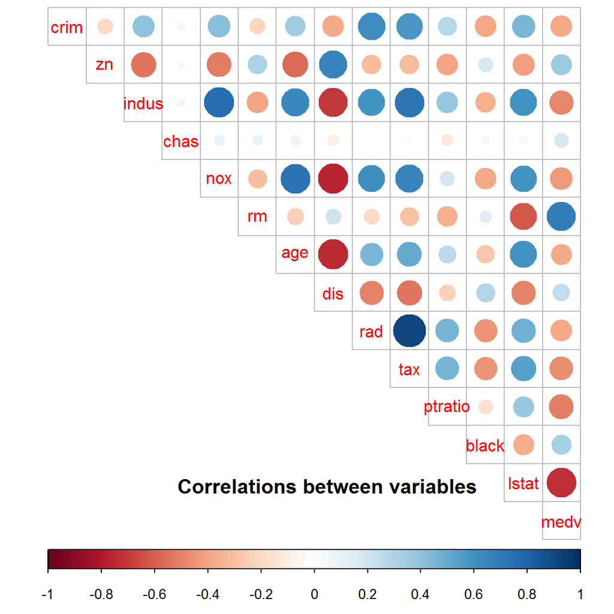

*Figure 4.3 Correlations between variables.*

```r
#Calculate the correlation matrix and round it
cor_matrix<-cor(Boston)

library(corrplot)
#Visualize the correlation matrix
corrplot(cor_matrix, method="circle", type="upper",cl.pos="b",tl.pos="d",tl.cex=1.0)
title("Correlations between variables",line=-20)
```

We can see that the strongest negative correlations are between dis and age, dis and nox, dis and indus and medv and lstat. The strongest positive correlations are between rad and tax, indus and nox, and indus and tax.

## Linear Discriminant Analysis

Linear discriminant analysis is a statistical method to find a linear combination to characterize the classes of a variable. It is thus somewhat distantly similar to regression analysis. It can be used to reduce dimensions, and so it is a little similar to Principal Component Analysis as well.

Before the analysis I standardized the variables in the data. That means that for every variable, I did the following: (variable - mean of the variable / standard deviation of that variable.

```r
#Center and standardize variables
boston_scaled <- scale(Boston)

#Summaries of the scaled variables
summary(boston_scaled)
```

```
##       crim                 zn               indus
##  Min.   :-0.419367   Min.   :-0.48724   Min.   :-1.5563
##  1st Qu.:-0.410563   1st Qu.:-0.48724   1st Qu.:-0.8668
##  Median :-0.390280   Median :-0.48724   Median :-0.2109
##  Mean   : 0.000000   Mean   : 0.00000   Mean   : 0.0000
##  3rd Qu.: 0.007389   3rd Qu.: 0.04872   3rd Qu.: 1.0150
##  Max.   : 9.924110   Max.   : 3.80047   Max.   : 2.4202
##       chas              nox                rm               age
##  Min.   :-0.2723   Min.   :-1.4644   Min.   :-3.8764   Min.   :-2.3331
##  1st Qu.:-0.2723   1st Qu.:-0.9121   1st Qu.:-0.5681   1st Qu.:-0.8366
##  Median :-0.2723   Median :-0.1441   Median :-0.1084   Median : 0.3171
##  Mean   : 0.0000   Mean   : 0.0000   Mean   : 0.0000   Mean   : 0.0000
##  3rd Qu.:-0.2723   3rd Qu.: 0.5981   3rd Qu.: 0.4823   3rd Qu.: 0.9059
##  Max.   : 3.6648   Max.   : 2.7296   Max.   : 3.5515   Max.   : 1.1164
##       dis               rad               tax             ptratio
##  Min.   :-1.2658   Min.   :-0.9819   Min.   :-1.3127   Min.   :-2.7047
##  1st Qu.:-0.8049   1st Qu.:-0.6373   1st Qu.:-0.7668   1st Qu.:-0.4876
##  Median :-0.2790   Median :-0.5225   Median :-0.4642   Median : 0.2746
##  Mean   : 0.0000   Mean   : 0.0000   Mean   : 0.0000   Mean   : 0.0000
##  3rd Qu.: 0.6617   3rd Qu.: 1.6596   3rd Qu.: 1.5294   3rd Qu.: 0.8058
##  Max.   : 3.9566   Max.   : 1.6596   Max.   : 1.7964   Max.   : 1.6372
##      black             lstat              medv
##  Min.   :-3.9033   Min.   :-1.5296   Min.   :-1.9063
##  1st Qu.: 0.2049   1st Qu.:-0.7986   1st Qu.:-0.5989
##  Median : 0.3808   Median :-0.1811   Median :-0.1449
##  Mean   : 0.0000   Mean   : 0.0000   Mean   : 0.0000
##  3rd Qu.: 0.4332   3rd Qu.: 0.6024   3rd Qu.: 0.2683
##  Max.   : 0.4406   Max.   : 3.5453   Max.   : 2.9865
```

```r
#Make boston_scaled into a dataframe
boston_scaled<-as.data.frame(boston_scaled)
```

We can now see that all the variables have 0 as their mean.

```r
#Use gather() to gather columns into key-value pairs and then glimpse() at the resulting data
gather(boston_scaled) %>% glimpse
```

```
## Observations: 7,084
## Variables: 2
## $ key   <chr> "crim", "crim", "crim", "crim", "crim", "crim", "crim", ...
## $ value <dbl> -0.4193669, -0.4169267, -0.4169290, -0.4163384, -0.41207...
```

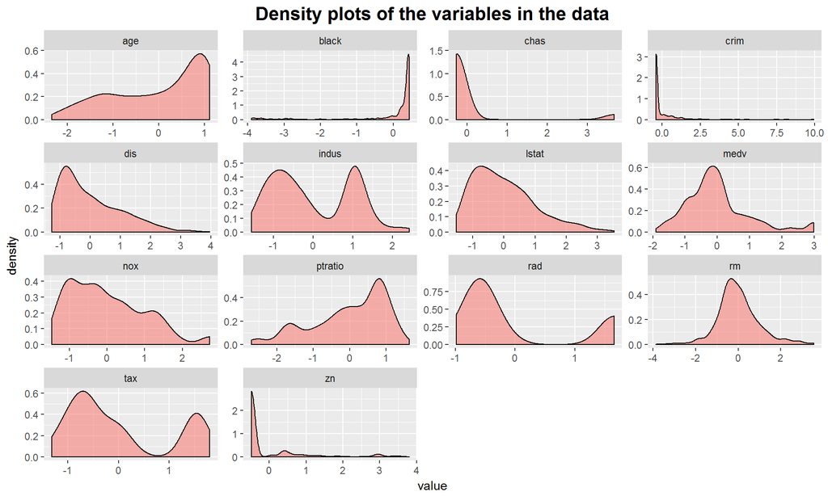

*Figure 4.4 Density plots of the variables in Boston-data.*

```r
#Draw a density plot of each variable
gather(boston_scaled) %>% ggplot(aes(value,fill="#99999",alpha=0.3)) + facet_wrap("key", scales = "free") +
  geom_density() +
  ggtitle("Density plots of the variables in the data") +
  theme(plot.title = element_text(hjust = 0.5,size=16,face='bold'),legend.position="none")
```

By looking at the density plots now we can maybe understand a bit better what just happened. The distributions still seem the same but the scales are different now.

Then I created a categorical variable of the crime rate variable by using the code provided in DataCamp. I removed the original crime rate variable from the dataset and added the new categorical one into it.

```r
#Save the scaled crim as scaled_crim
scaled_crim <- boston_scaled$crim

#Summary of the scaled_crim
summary(scaled_crim)
```

```
##      Min.   1st Qu.    Median      Mean   3rd Qu.      Max.
## -0.419400 -0.410600 -0.390300  0.000000  0.007389  9.924000
```

```r
#Create a quantile vector of crim and print it
bins <- quantile(scaled_crim)
bins
```

```
##           0%          25%          50%          75%         100%
## -0.419366929 -0.410563278 -0.390280295  0.007389247  9.924109610
```

```r
#Create a categorical variable 'crime'
crime <- cut(scaled_crim, breaks = bins, include.lowest = TRUE, label=c("low","med_low","med_high","high"))

#Remove original crim from the dataset
boston_scaled <- dplyr::select(boston_scaled, -crim)

#Add the new categorical value to scaled data
boston_scaled <- data.frame(boston_scaled, crime)
```

The new crime rate variable is categorized so that the first quartile is the lowest category, the second quartile the second lowest, third quartile the second highest and fourth quartile the highest category.

Next I created the training set and the test set. The training set contains 80 % randomly selected rows from the boston_scaled -dataset and the test set contains the rest.

```r
#Save the number of rows in the Boston dataset into n
n <- nrow(boston_scaled)

#Choose randomly 80% of the rows
ind <- sample(n,  size = n * 0.8)

#Create train set
train <- boston_scaled[ind,]

#Create test set
test <- boston_scaled[-ind,]
```

Train-set has 404 observations and test-set 102 variables.

Then I proceeded to perform the LDA.

```r
#Linear discriminant analysis
lda.fit <- lda(crime ~ . , data = train)

#Print the lda.fit object
lda.fit
```

```
## Call:
## lda(crime ~ ., data = train)
##
## Prior probabilities of groups:
##       low   med_low  med_high      high
## 0.2599010 0.2351485 0.2524752 0.2524752
##
## Group means:
##                   zn      indus        chas        nox          rm
## low       1.09268020 -0.9945230 -0.08484810 -0.9145178  0.51768882
## med_low  -0.04718537 -0.3725663 -0.06511327 -0.6059140 -0.09883749
## med_high -0.38551208  0.1813612  0.22945822  0.3639829  0.09951997
## high     -0.48724019  1.0171096 -0.04073494  1.0499666 -0.40103155
##                 age        dis        rad        tax     ptratio
## low      -0.9415469  0.9388296 -0.6931138 -0.7421794 -0.47391945
## med_low  -0.3800904  0.4116253 -0.5357824 -0.4900704 -0.09955613
## med_high  0.4478850 -0.3768169 -0.4166453 -0.3138419 -0.22898021
## high      0.8443416 -0.8631523  1.6382099  1.5141140  0.78087177
##               black       lstat       medv
## low       0.3830400 -0.81662081  0.6170217
## med_low   0.3398481 -0.16881024  0.0409550
## med_high  0.1524503  0.08606337  0.1184876
## high     -0.7586838  0.89436853 -0.7099914
##
## Coefficients of linear discriminants:
##                 LD1          LD2          LD3
## zn       0.08656810  0.607008493 -0.960326112
## indus    0.07357455 -0.474230832  0.261216866
## chas    -0.07431205 -0.083621997 -0.009049349
## nox      0.35597019 -0.609607795 -1.368357513
## rm      -0.07332151 -0.128173802 -0.237481746
## age      0.29108322 -0.322853854 -0.141967071
## dis     -0.05278736 -0.186042044  0.211273788
## rad      3.11275240  0.951311755  0.115074658
## tax      0.03493951  0.146340214  0.490539035
## ptratio  0.11081997 -0.019579947 -0.380818405
## black   -0.15529995  0.005235367  0.174866002
## lstat    0.19725037 -0.187559035  0.280610716
## medv     0.16781705 -0.269107547 -0.178647101
##
## Proportion of trace:
##    LD1    LD2    LD3
## 0.9447 0.0428 0.0125
```

```r
#The function for lda biplot arrows
lda.arrows <- function(x, myscale = 1, arrow_heads = 0.1, color = "red", tex = 0.75, choices = c(1,2)){
  heads <- coef(x)
  arrows(x0 = 0, y0 = 0,
         x1 = myscale * heads[,choices[1]],
         y1 = myscale * heads[,choices[2]], col=color, length = arrow_heads)
  text(myscale * heads[,choices], labels = row.names(heads),
       cex = tex, col=color, pos=3)
}

#Target classes as numeric
classes <- as.numeric(train$crime)
```

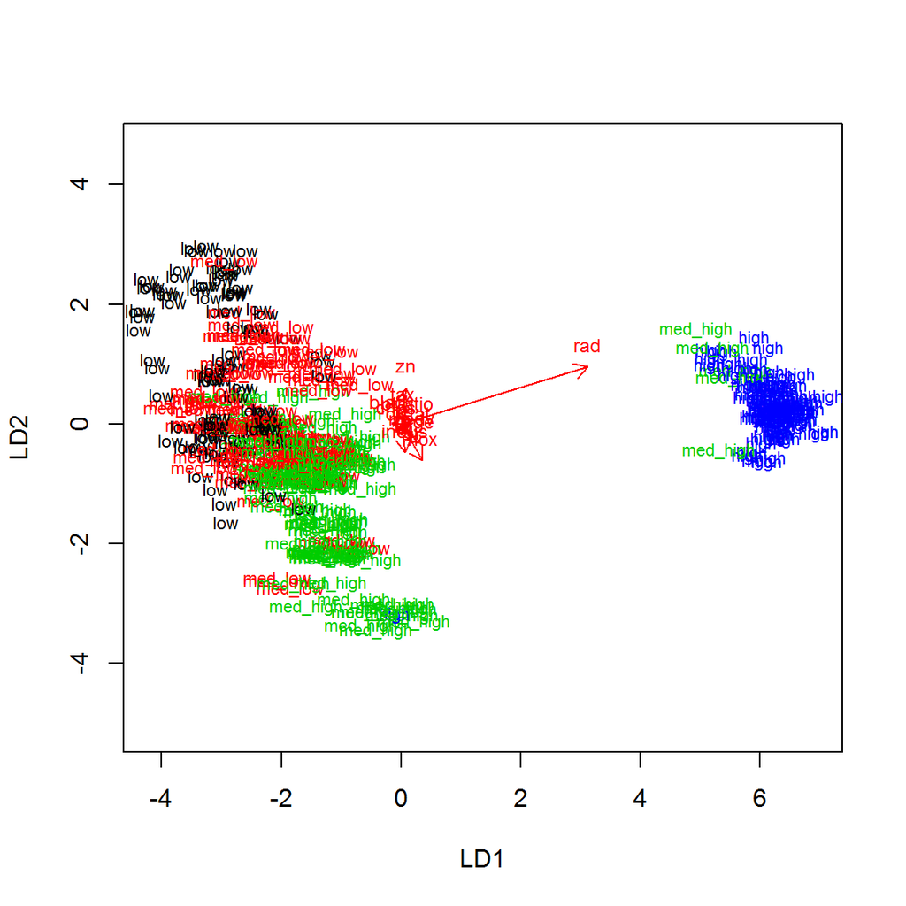

*Figure 4.5 Results of the Linear Discriminant Analysis.*

```r
#Plot the lda results
plot(lda.fit, dimen = 2,col=classes,pch=classes)
lda.arrows(lda.fit, myscale=1)
```

Wee can see that the high crime rate class really stands out, whereas all the rest seem to be together.

After that I saved the crime categories from the test set and removed the categorical crime variable from the test dataset.

```r
#Save the correct classes from test data
correct_classes <- test$crime

#Remove the crime variable from test data
test <- dplyr::select(test, -crime)
```

Then I used the LDA model on the test data to explain the categories of the crime variable.

```r
#Predict classes with test data
lda.pred <- predict(lda.fit, newdata = test)

#Cross tabulate the results
table(correct = correct_classes, predicted = lda.pred$class)
```

```
##           predicted
## correct    low med_low med_high high
##   low        8      11        3    0
##   med_low    3      17       11    0
##   med_high   0       7       16    1
##   high       0       0        0   25
```

## Distances and clustering

I reloaded the Boston-dataset and scaled it once again.

```r
data("Boston")
#Center and standardize variables
boston_scaled <- scale(Boston)
#Make boston_scaled into a dataframe
boston_scaled<-as.data.frame(boston_scaled)
```

The exercise tells me to calculate distances between observations and since it is not specified which distances should be used, I chose to use Euclidean distances because they are the most common.

```r
#Euclidean distance matrix
dist_eu <- dist(boston_scaled)
```

Then I run k-means on the distances. First I used 15 clusters.

```r
#k-means clustering
km <-kmeans(dist_eu, centers = 15)
```

I was trying to determine the right amount of clusters so I ran these codes from the DataCamp exercises:

```r
#Determine the number of clusters
k_max <- 10

#Calculate the total within sum of squares
twcss <- sapply(1:k_max, function(k){kmeans(dist_eu, k)$tot.withinss})
```

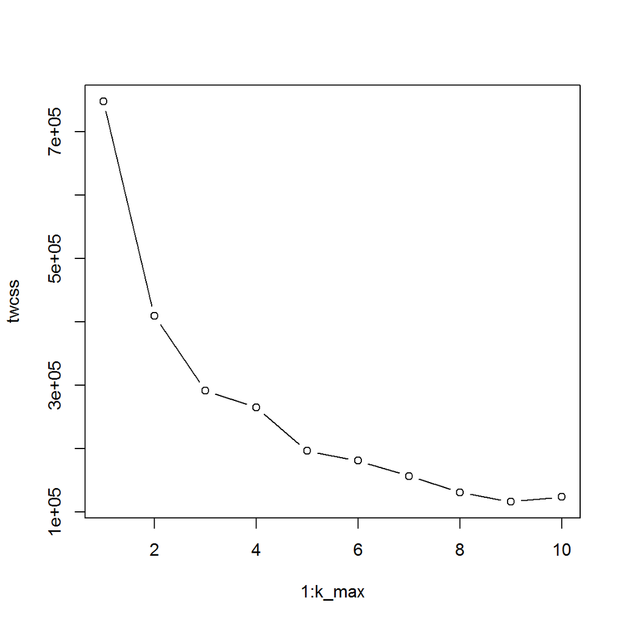

*Figure 4.6 Results of k-means clustering.*

```r
#Visualize the results
plot(1:k_max, twcss, type='b')
```

We can see from the plot that the most radical change happens at 2, so the right number of clusters to be used is 2. So I performed the k-means clustering again, this time with two clusters.

```r
#k-means clustering
km <-kmeans(dist_eu, centers = 2)
```

And finally, here is the graphical representation of the clusters:

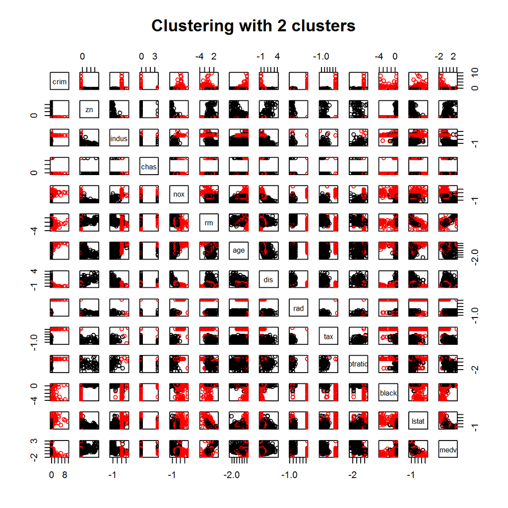

*Figure 4.7 Results of k-means clustering with 2 clusters.*

```r
pairs(boston_scaled, col = km$cluster,main="Clustering with 2 clusters")
```

I was maybe expecting something even more clear from this graph. But it can be seen that most often the black and red spots separate from each other and are rarely mixed. In some plots a clear pattern can be seen, for example in the plot between tax and crim. But for example between ptratio and medv, the clusters are not very clearle separated from each others.

# Week FIVE

This week we learned about dimensionality reduction. I have some previous knowledge about some of these techniques but I find it useful to refresh my memory since these are still pretty difficult to me. Dimensionality reduction can sometimes seem pretty abstract in my opinion!

First I read the dataset human back into RStudio and checked its structure and dimensions

```r
#Read the data
setwd("C:/Users/Paula/Documents/GitHub/IODS-project/data")
human<-read.csv("human.csv",header=T,sep="")
```

```r
#Explore the data
dim(human)
```

```
## [1] 155   8
```

```r
str(human)
```

```
## 'data.frame':    155 obs. of  8 variables:
##  $ Pop2edR : num  1.007 0.997 0.983 0.989 0.969 ...
##  $ LFPRMR  : num  0.891 0.819 0.825 0.884 0.829 ...
##  $ EYE     : num  17.5 20.2 15.8 18.7 17.9 16.5 18.6 16.5 15.9 19.2 ...
##  $ LEatB   : num  81.6 82.4 83 80.2 81.6 80.9 80.9 79.1 82 81.8 ...
##  $ GNI     : int  64992 42261 56431 44025 45435 43919 39568 52947 42155 32689 ...
##  $ MatMort : int  4 6 6 5 6 7 9 28 11 8 ...
##  $ AdBirthr: num  7.8 12.1 1.9 5.1 6.2 3.8 8.2 31 14.5 25.3 ...
##  $ RepParl : num  39.6 30.5 28.5 38 36.9 36.9 19.9 19.4 28.2 31.4 ...
```

The dataset has 155 observations and 8 variables. The rows are named with country names instead of numbers (from 1-155) as usual. The variables are all numeric or integer and related to health and knowledge and empowerment. There is * Pop2edR that is the ratio of female and male populations with secondary education in each country * LFPRMR that is the ratio of labour force participation of females and males in each country * EYE that is the expected years of education * LEatB that is life expectancy at birth * GNI that is gross national income per capita * MatMort that is maternal mortality ratio * AdBirth that is adolescent birth rate * RepParl that is percetange of female representatives in parliament

I then looked at the graphics of the variables. Since all are either numeric or integer, I decided to look at the density plots to understand better the distributions of the variables.

```r
#Access the tidyverse libraries tidyr, dplyr, ggplot2
library(tidyr); library(dplyr); library(ggplot2)
```

```r
#Use gather() to gather columns into key-value pairs and then glimpse() at the resulting data
gather(human) %>% glimpse
```

```
## Observations: 1,240
## Variables: 2
## $ key   <chr> "Pop2edR", "Pop2edR", "Pop2edR", "Pop2edR", "Pop2edR", "...
## $ value <dbl> 1.0072389, 0.9968288, 0.9834369, 0.9886128, 0.9690608, 0...
```

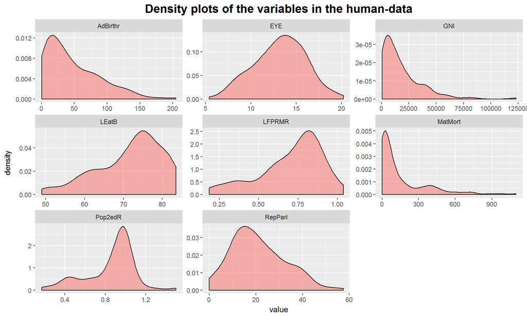

*Figure 5.1 Density plots of the variables in human-data.*

```r
#Draw a density plot of each variable
gather(human) %>% ggplot(aes(value,fill="#99999",alpha=0.3)) + facet_wrap("key", scales = "free") +
  geom_density() +
  ggtitle("Density plots of the variables in the human-data") +
  theme(plot.title = element_text(hjust = 0.5,size=16,face='bold'),legend.position="none")
```

We can see that the most normally distributed variable seems to be expected years of education. Luckily maternal mortality and adolescent births peak near zero. Unfortunately it seems that the mode of the feminine representation in parliament is under 20. It also seems that most of the countries have quite low gross national income and only some of them have high.

Then I took a look at the relationships between variables by plotting them against each other.

```r
library("GGally")
```

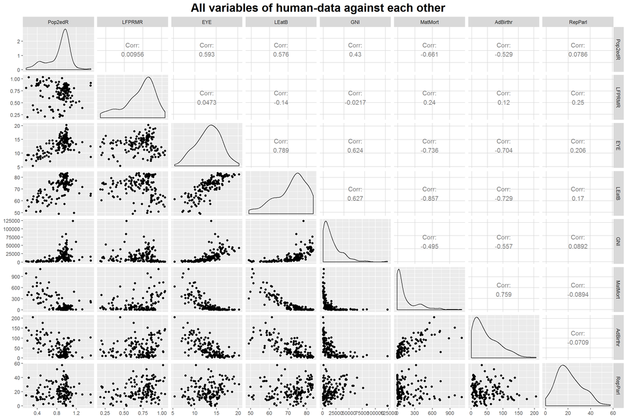

*Figure 5.2 All variables against each other.*

```r
#Create and draw a more advanced plot matrix with ggpairs()
p2 <- ggpairs(human,
             lower = list(combo = wrap("facethist", bins = 20))) +
  ggtitle("All variables of human-data against each other") +
  theme(plot.title = element_text(hjust = 0.5,size=20,face='bold'))
p2
```

The strongest correlation can be found between maternal mortality and life expectancy at birth (-0.857). It is a negative correlation and that means more maternal mortality there is, the less the child is expected to live. That makes sense, even though I think it’s very sad. Expected years of education correlate also quite strongly with maternal mortality. More maternal mortality there is, the less are the expected years of schooling. In general it can be said that the data is quite correlated. The least correlation there is between the ratio of female and male populations with secondary education in each country and the ratio of labour force participation of females and males in each country (0.00956).

## Principal Component Analysis

### Principal Component Analysis on unstandardized data

Next I proceeded into performing principal component analysis on the human data.

```r
#Perform principal component analysis (with the SVD method)
pca_human1 <- prcomp(human)
pca_human1
```

```
## Standard deviations:
## [1] 1.854416e+04 1.855219e+02 2.518701e+01 1.145441e+01 3.766241e+00
## [6] 1.565912e+00 1.912052e-01 1.591112e-01
##
## Rotation:
##                    PC1           PC2           PC3           PC4
## Pop2edR  -5.607472e-06  0.0006713951 -3.412027e-05 -2.736326e-04
## LFPRMR    2.331945e-07 -0.0002819357  5.302884e-04 -4.692578e-03
## EYE      -9.562910e-05  0.0075529759  1.427664e-02 -3.313505e-02
## LEatB    -2.815823e-04  0.0283150248  1.294971e-02 -6.752684e-02
## GNI      -9.999832e-01 -0.0057723054 -5.156742e-04  4.932889e-05
## MatMort   5.655734e-03 -0.9916320120  1.260302e-01 -6.100534e-03
## AdBirthr  1.233961e-03 -0.1255502723 -9.918113e-01  5.301595e-03
## RepParl  -5.526460e-05  0.0032317269 -7.398331e-03 -9.971232e-01
##                    PC5           PC6           PC7           PC8
## Pop2edR  -0.0022935252  2.180183e-02  6.998623e-01  7.139410e-01
## LFPRMR    0.0022190154  3.264423e-02  7.132267e-01 -7.001533e-01
## EYE       0.1431180282  9.882477e-01 -3.826887e-02  7.776451e-03
## LEatB     0.9865644425 -1.453515e-01  5.380452e-03  2.281723e-03
## GNI      -0.0001135863 -2.711698e-05 -8.075191e-07 -1.176762e-06
## MatMort   0.0266373214  1.695203e-03  1.355518e-04  8.371934e-04
## AdBirthr  0.0188618600  1.273198e-02 -8.641234e-05 -1.707885e-04
## RepParl  -0.0716401914 -2.309896e-02 -2.642548e-03  2.680113e-03
```

```r
pca_human1b<-summary(pca_human1)
pca_pr <- round(100*pca_human1b$importance[2, ], digits = 1)

#Print out the percentages of variance
pca_pr
```

```
## PC1 PC2 PC3 PC4 PC5 PC6 PC7 PC8
## 100   0   0   0   0   0   0   0
```

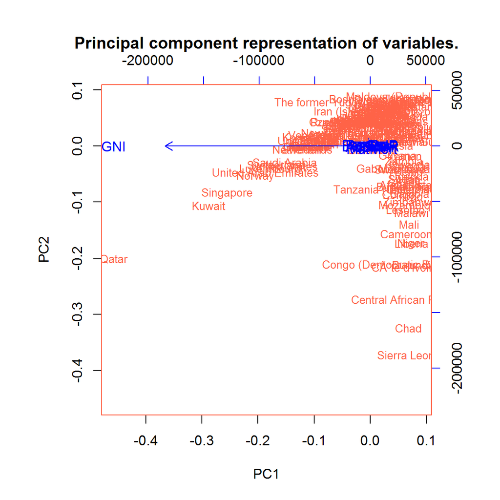

*Figure 5.3 Principal component representation. GNI on the x-axis, no other dimensions standing out. PC1 explaining 100 % of the variation between countries and PC2 0 %.*

```r
#Draw a biplot of the principal component representation and the original variables
biplot(pca_human1, choices = 1:2,cex = c(0.8, 1),col = c("tomato", "blue"),main="Principal component representation of variables.")
```

We can see that in this case all the variability is explained by the first principal component. The plot doesn’t seem very informative: Only the arrow for GNI is visible because the others have length 0. So that is exactly what the percentages are showing as well: GNI 100 % and others 0. Most of the countries are all together in one unclear spot. But for example Qatar stands out: It has drammatically higher GNI than any other country in the data.

### Principal Component Analysis on standardized data

I then performed the principal component analysis on the standardized human data.

```r
#Standardize the variables
human_std <- scale(human)

#Print out summaries and standard deviations of the standardized variables
summary(human_std)
```

```
##     Pop2edR            LFPRMR             EYE              LEatB
##  Min.   :-2.8189   Min.   :-2.6247   Min.   :-2.7378   Min.   :-2.7188
##  1st Qu.:-0.5233   1st Qu.:-0.5484   1st Qu.:-0.6782   1st Qu.:-0.6425
##  Median : 0.3503   Median : 0.2316   Median : 0.1140   Median : 0.3056
##  Mean   : 0.0000   Mean   : 0.0000   Mean   : 0.0000   Mean   : 0.0000
##  3rd Qu.: 0.5958   3rd Qu.: 0.7350   3rd Qu.: 0.7126   3rd Qu.: 0.6717
##  Max.   : 2.6646   Max.   : 1.6632   Max.   : 2.4730   Max.   : 1.4218
##       GNI             MatMort           AdBirthr          RepParl
##  Min.   :-0.9193   Min.   :-0.6992   Min.   :-1.1325   Min.   :-1.8203
##  1st Qu.:-0.7243   1st Qu.:-0.6496   1st Qu.:-0.8394   1st Qu.:-0.7409
##  Median :-0.3013   Median :-0.4726   Median :-0.3298   Median :-0.1403
##  Mean   : 0.0000   Mean   : 0.0000   Mean   : 0.0000   Mean   : 0.0000
##  3rd Qu.: 0.3712   3rd Qu.: 0.1932   3rd Qu.: 0.6030   3rd Qu.: 0.6127
##  Max.   : 5.6890   Max.   : 4.4899   Max.   : 3.8344   Max.   : 3.1850
```

```r
apply(human_std,2,sd)
```

```
##  Pop2edR   LFPRMR      EYE    LEatB      GNI  MatMort AdBirthr  RepParl
##        1        1        1        1        1        1        1        1
```

```r
#Perform principal component analysis (with the SVD method)
pca_human2 <- prcomp(human_std)
pca_human2
```

```
## Standard deviations:
## [1] 2.0708380 1.1397204 0.8750485 0.7788630 0.6619563 0.5363061 0.4589994
## [8] 0.3222406
##
## Rotation:
##                  PC1         PC2         PC3         PC4        PC5
## Pop2edR  -0.35664370  0.03796058 -0.24223089  0.62678110 -0.5983585
## LFPRMR    0.05457785  0.72432726 -0.58428770  0.06199424  0.2625067
## EYE      -0.42766720  0.13940571 -0.07340270 -0.07020294  0.1659678
## LEatB    -0.44372240 -0.02530473  0.10991305 -0.05834819  0.1628935
## GNI      -0.35048295  0.05060876 -0.20168779 -0.72727675 -0.4950306
## MatMort   0.43697098  0.14508727 -0.12522539 -0.25170614 -0.1800657
## AdBirthr  0.41126010  0.07708468  0.01968243  0.04986763 -0.4672068
## RepParl  -0.08438558  0.65136866  0.72506309  0.01396293 -0.1523699
##                  PC6         PC7         PC8
## Pop2edR   0.17713316  0.05773644  0.16459453
## LFPRMR   -0.03500707 -0.22729927 -0.07304568
## EYE      -0.38606919  0.77962966 -0.05415984
## LEatB    -0.42242796 -0.43406432  0.62737008
## GNI       0.11120305 -0.13711838 -0.16961173
## MatMort   0.17370039  0.35380306  0.72193946
## AdBirthr -0.76056557 -0.06897064 -0.14335186
## RepParl   0.13749772  0.00568387 -0.02306476
```

```r
pca_human2b<-summary(pca_human2)
pca_pr2 <- round(100*pca_human2b$importance[2, ], digits = 1)

#Print out the percentages of variance
pca_pr2
```

```
##  PC1  PC2  PC3  PC4  PC5  PC6  PC7  PC8
## 53.6 16.2  9.6  7.6  5.5  3.6  2.6  1.3
```

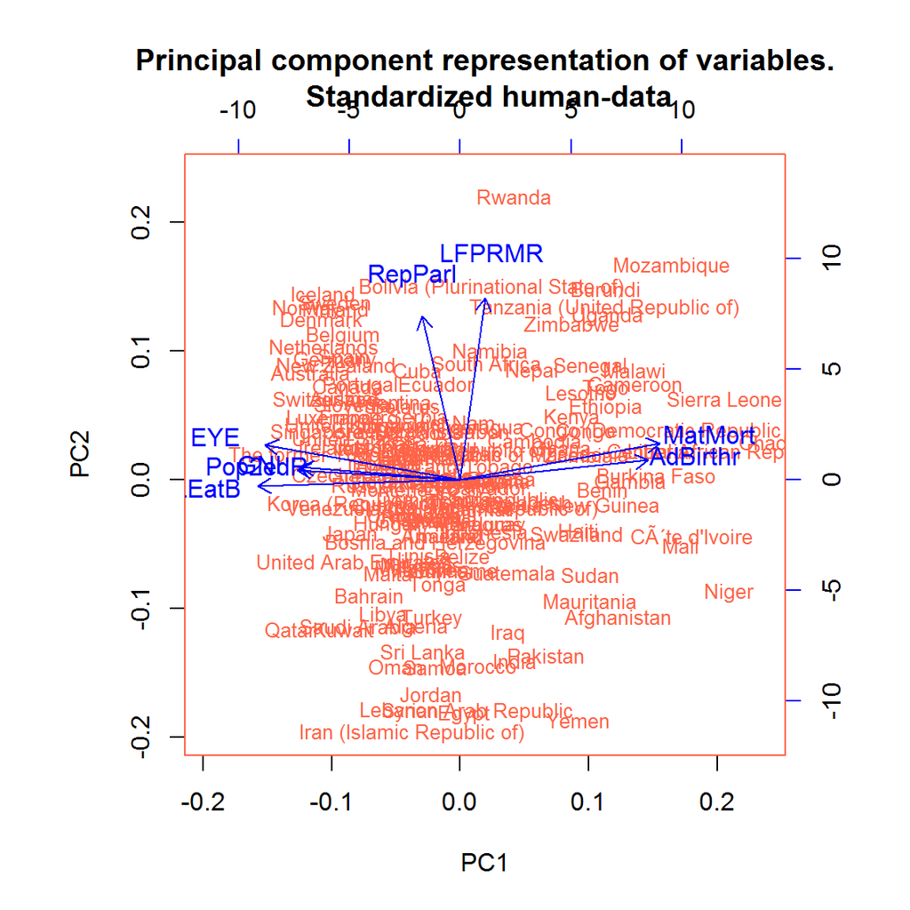

*Figure 5.4 Principal component representation. Standardized human-data. PC1 explaining 53.6 % of the variation between countries and PC2 explaining 16.2 %.*

```r
#Draw a biplot of the principal component representation and the original variables
biplot(pca_human2, choices = 1:2,cex = c(0.8, 1),col = c("tomato", "blue"),main="Principal component representation of variables.\n Standardized human-data")
```

Now the situation is much clearer. The standardation sets all variables standard deviation to 1 and mean to 0 so the variables are more meaningful to handle together this way. We can see that the first component explains 53.6 % of the variation and second principal component explains 16.2 %, after that the percents are already drammatically lower.

As was stated earlier, maternal mortality and life expectancy at birth correlate negatively and very strongly with each other, and this can be seen from the figure as well: Those two variables have their arrows pointing to totally opposite directions. Maternal mortality has strong, positive correlation with adolescent birth ratio, that’s why their arrows are pointing almost towards the same direction.

So the life expectancy, GNI, expected years of education and the ratio of female and male populations with secondary education in each country on the other side and maternal mortality and adolescent birth ratio on the other seem to be responsible on the variation on x-axis. So the component could be called Well-being. More the countries are on the left, more well-being they are and vice versa. Parallel with the y-axis we can see the ratio of labour force participation of females and males in each country and female representation in parliament, pointing pretty much towards the same direction. So in my personal opinion this dimension of the figure could be called Feminism. Higher the countries are on the y-axis, more they have women working and in parliament.

## Multiple Correspondence Analysis on tea-dataset

Then I went on doing a multiple correspondence with tea-dataset from the package FactoMineR. Multiple correspondence analysis investigates multiple variables and treats them in a way that they could be presented in a two dimensional scale. An integral part of the analysis are the graphs: They present the relationships between the two dimensions but also the relationships between the classes of variables.

The variables in the analysis can’t be continuous. The method isn’t based on statistical testing and the main purpose of it is to *describe* with the help of the figures.

First I loaded the data and explored it a little bit.

```r
library("FactoMineR")
```

```r
data(tea)
```

```r
#Explore the data
dim(tea)
```

```
## [1] 300  36
```

```r
str(tea)
```

```
## 'data.frame':    300 obs. of  36 variables:
##  $ breakfast       : Factor w/ 2 levels "breakfast","Not.breakfast": 1 1 2 2 1 2 1 2 1 1 ...
##  $ tea.time        : Factor w/ 2 levels "Not.tea time",..: 1 1 2 1 1 1 2 2 2 1 ...
##  $ evening         : Factor w/ 2 levels "evening","Not.evening": 2 2 1 2 1 2 2 1 2 1 ...
##  $ lunch           : Factor w/ 2 levels "lunch","Not.lunch": 2 2 2 2 2 2 2 2 2 2 ...
##  $ dinner          : Factor w/ 2 levels "dinner","Not.dinner": 2 2 1 1 2 1 2 2 2 2 ...
##  $ always          : Factor w/ 2 levels "always","Not.always": 2 2 2 2 1 2 2 2 2 2 ...
##  $ home            : Factor w/ 2 levels "home","Not.home": 1 1 1 1 1 1 1 1 1 1 ...
##  $ work            : Factor w/ 2 levels "Not.work","work": 1 1 2 1 1 1 1 1 1 1 ...
##  $ tearoom         : Factor w/ 2 levels "Not.tearoom",..: 1 1 1 1 1 1 1 1 1 2 ...
##  $ friends         : Factor w/ 2 levels "friends","Not.friends": 2 2 1 2 2 2 1 2 2 2 ...
##  $ resto           : Factor w/ 2 levels "Not.resto","resto": 1 1 2 1 1 1 1 1 1 1 ...
##  $ pub             : Factor w/ 2 levels "Not.pub","pub": 1 1 1 1 1 1 1 1 1 1 ...
##  $ Tea             : Factor w/ 3 levels "black","Earl Grey",..: 1 1 2 2 2 2 2 1 2 1 ...
##  $ How             : Factor w/ 4 levels "alone","lemon",..: 1 3 1 1 1 1 1 3 3 1 ...
```

[output cut: 22 more lines]

The data has 36 variables and 300 observations. The variables are mostly factors, only age is integer. Actually also age has a factor version of it, called age_Q. Just by looking at the structure it is kind of hard to say what the data is all about. It has for example variables named by different meals of the day. Then there are a lot of adjective-variables such as feminine, sophisticated and healthy. To understand the data better, I looked what R:s Help tells about it.

```r
?tea
```

Help-page tells the following:

“Description: The data used here concern a questionnaire on tea. We asked to 300 individuals how they drink tea (18 questions), what are their product’s perception (12 questions) and some personal details (4 questions).

Format: A data frame with 300 rows and 36 columns. Rows represent the individuals, columns represent the different questions. The first 18 questions are active ones, the 19th is a supplementary quantitative variable (the age) and the last variables are supplementary categorical variables."

```r
#Use gather() to gather columns into key-value pairs and then glimpse() at the resulting data
gather(tea) %>% glimpse
```

```
## Observations: 10,800
## Variables: 2
## $ key   <chr> "breakfast", "breakfast", "breakfast", "breakfast", "bre...
## $ value <chr> "breakfast", "breakfast", "Not.breakfast", "Not.breakfas...
```

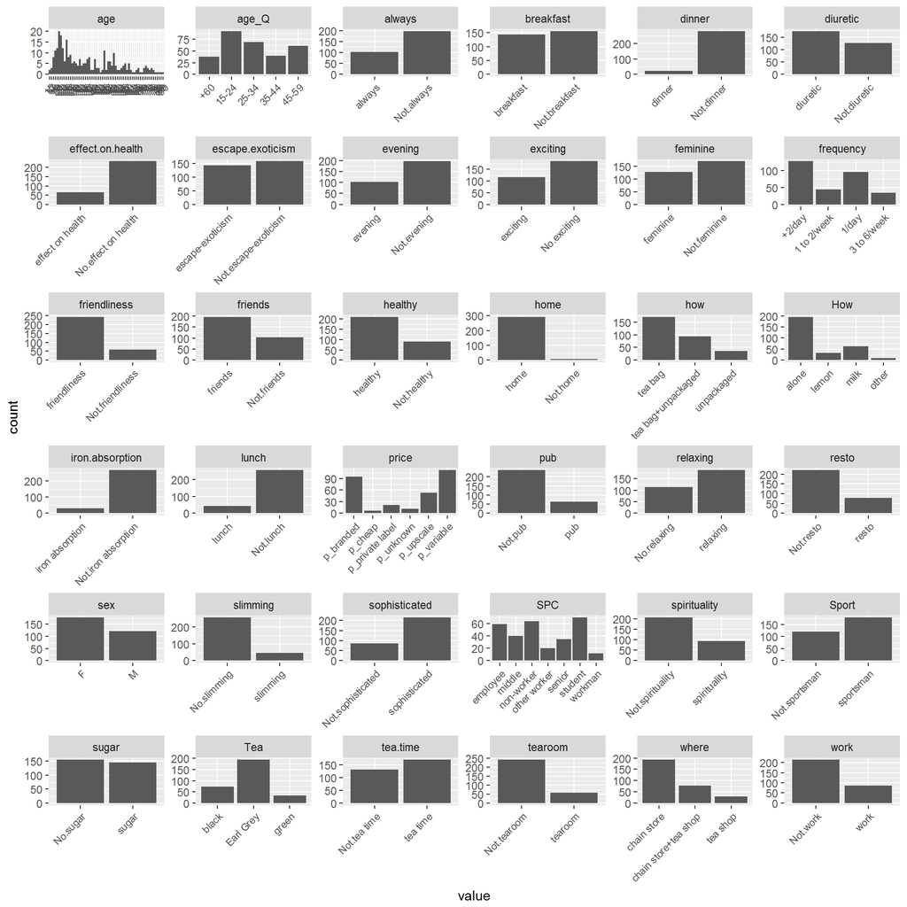

*Figure 5.5 Bar plots of the variables in tea-data.*

```r
#Draw a bar plot of each variable
gather(tea) %>% ggplot(aes(value)) + facet_wrap("key", scales = "free") + geom_bar() + theme(axis.text.x = element_text(angle = 45, hjust = 1, size = 8))
```

```r
teavars<-c("Tea","How","sugar","how","price","sex","age_Q")
tea_for_mca<-tea[teavars]
```

```r
#Multiple correspondence analysis
mca <- MCA(tea_for_mca, graph = FALSE)

#Summary of the model
summary(mca)
```

```
##
## Call:
## MCA(X = tea_for_mca, graph = FALSE)
##
##
## Eigenvalues
##                        Dim.1   Dim.2   Dim.3   Dim.4   Dim.5   Dim.6
## Variance               0.267   0.215   0.203   0.184   0.176   0.160
## % of var.             10.379   8.366   7.905   7.174   6.846   6.240
## Cumulative % of var.  10.379  18.745  26.651  33.825  40.671  46.911
##                        Dim.7   Dim.8   Dim.9  Dim.10  Dim.11  Dim.12
## Variance               0.152   0.147   0.139   0.132   0.124   0.123
## % of var.              5.901   5.728   5.391   5.130   4.838   4.781
## Cumulative % of var.  52.812  58.540  63.931  69.061  73.899  78.680
##                       Dim.13  Dim.14  Dim.15  Dim.16  Dim.17  Dim.18
## Variance               0.113   0.111   0.096   0.088   0.074   0.067
## % of var.              4.403   4.317   3.723   3.404   2.874   2.598
## Cumulative % of var.  83.083  87.400  91.124  94.528  97.402 100.000
##
## Individuals (the 10 first)
##              Dim.1    ctr   cos2    Dim.2    ctr   cos2    Dim.3    ctr
## 1         |  0.028  0.001  0.000 |  0.318  0.157  0.019 |  1.052  1.814
## 2         |  0.351  0.154  0.058 | -0.669  0.694  0.212 |  0.372  0.227
## 3         | -0.062  0.005  0.003 | -0.585  0.530  0.264 | -0.221  0.080
## 4         | -0.592  0.437  0.294 |  0.275  0.118  0.064 | -0.062  0.006
## 5         |  0.025  0.001  0.000 | -0.172  0.046  0.021 | -0.050  0.004
## 6         | -0.464  0.268  0.076 |  0.014  0.000  0.000 |  0.285  0.133
## 7         |  0.001  0.000  0.000 | -0.068  0.007  0.003 | -0.098  0.016
## 8         |  0.327  0.133  0.043 | -0.566  0.496  0.129 |  0.325  0.173
## 9         |  0.516  0.332  0.093 |  0.192  0.057  0.013 |  0.018  0.001
## 10        |  0.924  1.066  0.309 |  0.044  0.003  0.001 | -0.200  0.066
##             cos2
## 1          0.207 |
## 2          0.066 |
## 3          0.038 |
## 4          0.003 |
## 5          0.002 |
## 6          0.029 |
## 7          0.005 |
## 8          0.042 |
```

[output cut: 21 more lines]

```
## milk        0.283 |   0.970  13.896   0.250   8.651 |
## other      -4.459 |   0.194   0.079   0.001   0.590 |
## No.sugar   -9.413 |  -0.196   1.396   0.041  -3.505 |
## sugar       9.413 |   0.210   1.492   0.041   3.505 |
## tea bag    -3.234 |   0.532  11.258   0.370  10.514 |
##
## Categorical variables (eta2)
##             Dim.1 Dim.2 Dim.3
## Tea       | 0.429 0.034 0.064 |
## How       | 0.046 0.133 0.262 |
## sugar     | 0.174 0.296 0.041 |
## how       | 0.330 0.091 0.417 |
## price     | 0.415 0.098 0.449 |
## sex       | 0.024 0.433 0.071 |
## age_Q     | 0.449 0.421 0.119 |
```

The second table represents the dimensions on 10 first individuals of the data. The str-column describes each individual’s contribution to each dimension. Cos2 describes the quality on a scale from 0 to 1.

By looking at the first and second dimensions of the third table we can see the coordinates where the variable choices will be placed in the plot that will be presented below.

Next I plotted the results.

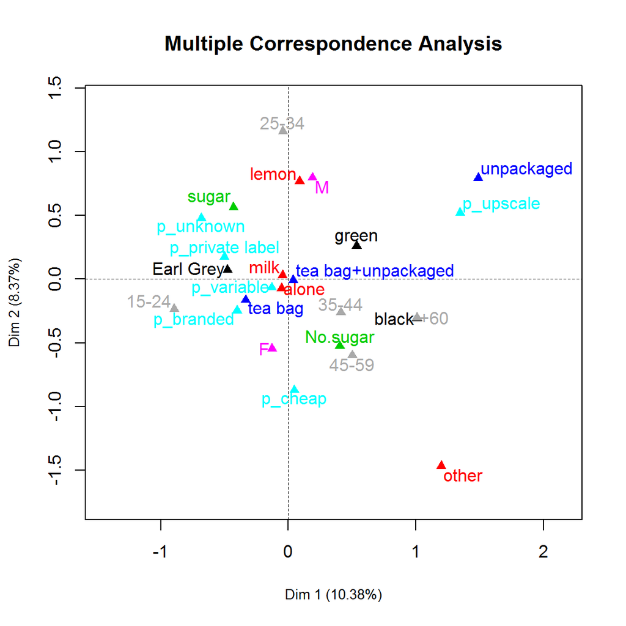

*Figure 5.6 Visualization of Multiple Correspondence Analysis.*

```r
#Visualize MCA
plot(mca,habillage="quali",
invisible="ind",cex=1.0,cex.lab=0.8,cex.axis=1.0,title="Multiple Correspondence Analysis",lwd=0.1, select="contrib 20")
```

I think that if the first two dimensions explain only about 20 % of the variation in the data, maybe the variables could have been chosen better. So maybe there would be some other variables that could explain each others variation better, but let’s leave that stay a mystery for now ;)